# Modelación

Author

Equipo 1

# Situacion Problema

### En base a la infomacion proporcionada por la Encuesta Origen Destino en Hogares de la Zona Metropolitana del Valle de México (EOD) 2017, se deben proporcionar respuestas a las siguientes Queries, usando el metodo de las redes DAG.

1. ¿Cuál es la probabilidad de que el tiempo de viaje sea menor a 20 minutos, dado que su medio de transporte fue el automóvil?
2. ¿Cuál es la probabilidad de que los viajes en Ciudad de México se hagan en medios no motorizados (caminar o bicicleta)?
3. ¿Cuál es la probabilidad de que un hogar de estrato medio bajo, utilicen más de 2 medios de transporte diferentes?
4. ¿Cuál es la probabilidad de que el viaje del hogar a la escuela dure más de 60 minutos si la persona viaja en coche?

Datos necesarios: - Tiempos de viaje por medio de transporte - Viajes en la ciudad de México por medio de transporte (motorizado/no motorizado) - # de medios de transporte por estratro de hogar - Tiempos de viaje de hogar a escuela por transporte

Relaciones de los datos: Viajes / Medio de transporte (1,2) Estrato hogar / # de medios de transporte Tiempo de viaje / Origen / Destino

```r
library(bnlearn)
```

```r
data = read.csv("../data/tviaje_clean.csv", stringsAsFactors = TRUE)
#head(data)
```

```r
# Todo a factor
data[] <- lapply(data, factor)
head(data)
```

| auto | colectivo | uber_etc | taxi | metro | bici | moto | caminar | entidad_origen | entidad_destino | tipo_origen | tipo_destino | estrato | tiempo |
| --- | --- | --- | --- | --- | --- | --- | --- | --- | --- | --- | --- | --- | --- |
| 2 | 2 | 2 | 2 | 2 | 2 | 2 | 1 | 9 | 9 | 1 | 3 | 3 | (40.0, 60.0] |
| 2 | 2 | 2 | 2 | 2 | 2 | 2 | 1 | 9 | 9 | 3 | 1 | 3 | (69.0, 95.0] |
| 2 | 2 | 2 | 2 | 2 | 2 | 2 | 1 | 9 | 9 | 1 | 7 | 3 | (0.999, 10.0] |
| 2 | 2 | 2 | 1 | 2 | 2 | 2 | 2 | 9 | 9 | 7 | 1 | 3 | (0.999, 10.0] |
| 2 | 2 | 2 | 2 | 2 | 2 | 2 | 1 | 9 | 9 | 1 | 3 | 3 | (40.0, 60.0] |
| 2 | 2 | 2 | 2 | 2 | 2 | 2 | 1 | 9 | 9 | 3 | 1 | 3 | (69.0, 95.0] |

```r
head(data["tiempo"])
```

| tiempo |
| --- |
| (40.0, 60.0] |
| (69.0, 95.0] |
| (0.999, 10.0] |
| (0.999, 10.0] |
| (40.0, 60.0] |
| (69.0, 95.0] |

```r
summary(data["tiempo"])
```

```
           tiempo
 (0.999, 10.0]:95625
 (40.0, 60.0] :87330
 (24.0, 30.0] :86442
 (10.0, 15.0] :60116
 (15.0, 20.0] :55829
 (69.0, 95.0] :54697
 (Other)      :91173
```

```r
# estructura DAGs planteadas

a = c(
  "moto", "tiempo",
  "estrato", "tiempo",
  "taxi", "tiempo",
  "auto", "tiempo",
  "entidad_origen", "tiempo",
  "entidad_destino", "tiempo",
  "caminar", "moto",
  "metro", "tipo_destino",
  "entidad_destino", "tipo_destino",
  "entidad_destino", "metro",
  "tipo_origen", "colectivo",
  "entidad_origen", "tipo_destino",
  "uber_etc", "taxi",
  "auto", "estrato"
)

b = c(
  "entidad_origen", "colectivo",
  "entidad_destino", "colectivo",
  "tipo_origen", "colectivo",
  "tipo_origen", "metro",
  "entidad_destino", "caminar",
  "entidad_origen", "caminar",
  "estrato", "entidad_origen",
  "entidad_destino", "uber_etc",
  "estrato", "uber_etc",
  "entidad_origen", "uber_etc",
  "bici", "tipo_destino",
  "entidad_origen", "tiempo",
  "auto", "tiempo",
  "moto", "tiempo",
  "entidad_destino", "tiempo",
  "uber_etc", "tiempo",
  "metro", "tiempo",
  "entidad_destino", "bici",
  "estrato", "auto",
  "estrato", "moto",
  "entidad_destino", "taxi",
  "estrato", "taxi"
)

c = c(
  "entidad_destino", "colectivo",
  "entidad_origen", "colectivo",
  "auto", "tiempo",
  "taxi", "tiempo",
  "metro", "tiempo",
  "moto", "tiempo",
  "uber_etc", "taxi",
  "metro", "taxi",
  "caminar", "metro",
  "entidad_destino", "tipo_destino",
  "entidad_origen", "bici",
  "entidad_origen", "moto",
  "estrato", "moto",
  "estrato", "auto",
  "estrato", "tipo_origen",
  "entidad_origen", "tipo_origen"
)
```

```r
arc_set_a <- matrix(a, byrow = TRUE, ncol = 2, dimnames = list(NULL, c("from", "to")))
arc_set_b <- matrix(b, byrow = TRUE, ncol = 2, dimnames = list(NULL, c("from", "to")))
arc_set_c <- matrix(c, byrow = TRUE, ncol = 2, dimnames = list(NULL, c("from", "to")))
```

```r
nodes <- names(data)

dag_a <- empty.graph(nodes = nodes)
dag_b = dag_a
dag_c = dag_a
```

```r
arcs(dag_a) <- arc_set_a
arcs(dag_b) <- arc_set_b
arcs(dag_c) <- arc_set_c
```

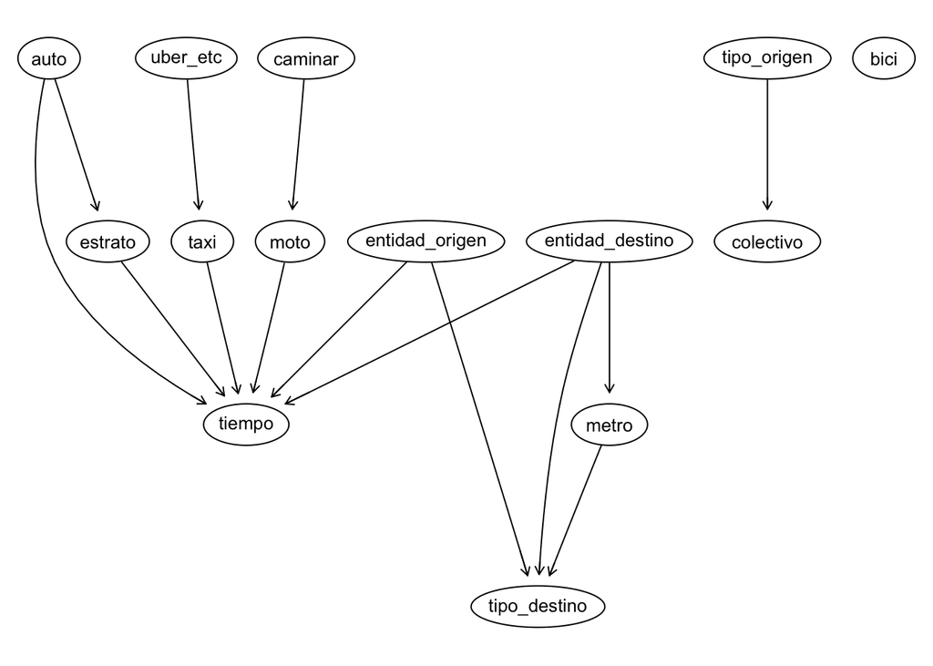

```r
graphviz.plot(dag_a, shape = "ellipse")
```

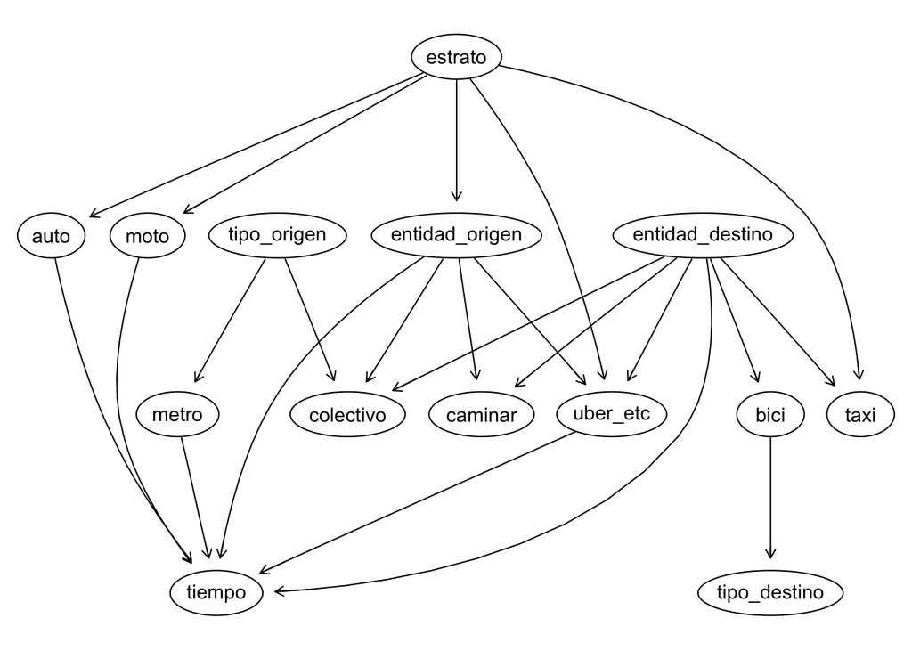

```r
graphviz.plot(dag_b, shape = "ellipse")
```

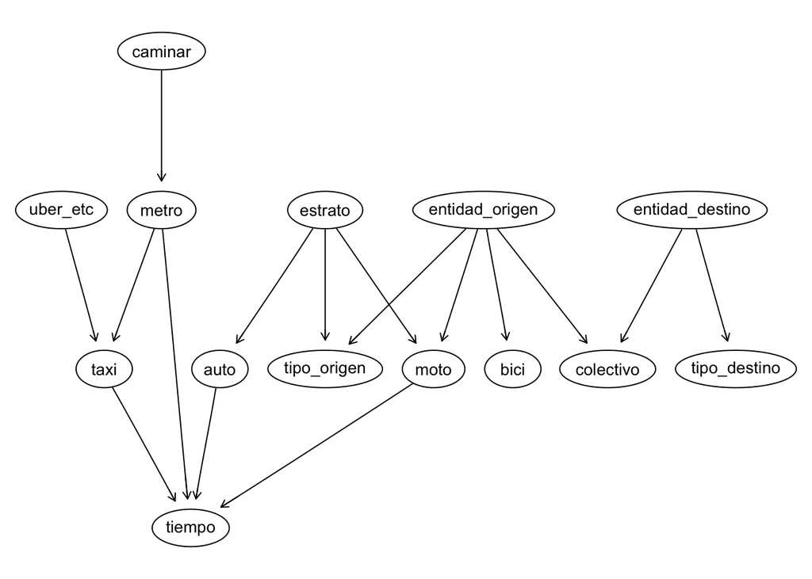

```r
graphviz.plot(dag_c, shape = "ellipse")
```

```r
# DAG mixta (discretas + continuas): BIC-CG
dag <- hc(data, score = "bic")
dag
```

```
  Bayesian network learned via Score-based methods

  model:
   [auto][uber_etc|auto][taxi|auto:uber_etc][bici|auto:uber_etc:taxi]
   [colectivo|auto:uber_etc:taxi:bici][moto|auto:colectivo:taxi:bici]
   [caminar|auto:colectivo:uber_etc:taxi:bici:moto]
   [tiempo|auto:colectivo:taxi:bici:caminar][tipo_origen|auto:taxi:tiempo]
   [tipo_destino|tipo_origen:tiempo][estrato|auto:colectivo:tipo_origen]
   [metro|auto:colectivo:caminar:estrato:tiempo]
   [entidad_origen|colectivo:metro:estrato]
   [entidad_destino|metro:entidad_origen]
  nodes:                                 14
  arcs:                                  43
    undirected arcs:                     0
    directed arcs:                       43
  average markov blanket size:           6.71
  average neighbourhood size:            6.14
  average branching factor:              3.07

  learning algorithm:                    Hill-Climbing
  score:                                 BIC (disc.)
  penalization coefficient:              6.591458
  tests used in the learning procedure:  676
  optimized:                             TRUE
```

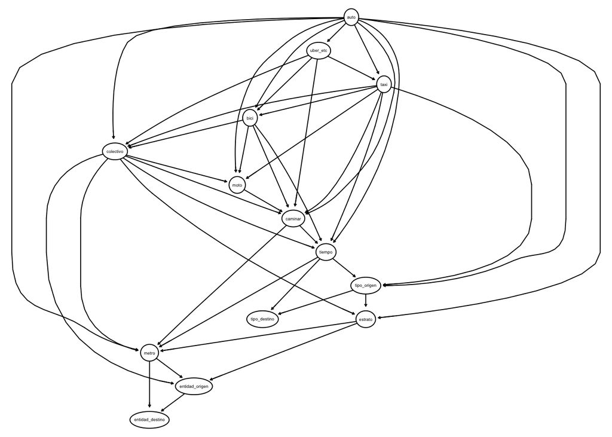

```r
graphviz.plot(dag, shape = "ellipse")
```

```r
scores <- c(
  dag_a = score(dag_a, data = data, type = "bic"),
  dag_b = score(dag_b, data = data, type = "bic"),
  dag_c = score(dag_c, data = data, type = "bic"),
  dag = score(dag, data = data, type = "bic")
)

scores
```

```
   dag_a    dag_b    dag_c      dag
-6916796 -6223229 -5544626 -4653180
```

```r
scores <- c(
  dag_a = score(dag_a, data = data, type = "aic"),
  dag_b = score(dag_b, data = data, type = "aic"),
  dag_c = score(dag_c, data = data, type = "aic"),
  dag = score(dag, data = data, type = "aic")
)

scores
```

```
   dag_a    dag_b    dag_c      dag
-5722651 -5602247 -5528259 -4620061
```

```r
bn <- bn.fit(dag, data = data)
```

1. ¿Cuál es la probabilidad de que el tiempo de viaje sea menor a 20 minutos, dado que su medio de transporte fue el automóvil?

```r
set.seed(1809)
cpquery(bn, event = (tiempo == "(0.999, 10.0]" | tiempo == "(10.0, 15.0]" | tiempo == "(15.0, 20.0]"), evidence = (auto == 1), n = 10^6)
```

```
[1] 0.3195917
```

2. ¿Cuál es la probabilidad de que los viajes en Ciudad de México se hagan en medios no motorizados (caminar o bicicleta)?

caminar= 1 (verdadero) bici= 1 (verdadero)

entidad_origen = 9 (CDMX) entidad_destino= 9 (CDMX)

```r
set.seed(1809)
cpquery(bn, event = (caminar == 1 | bici == 1), evidence = (entidad_origen == 9 & entidad_destino == 9), n = 10^6)
```

```
[1] 0.6171179
```

3. ¿Cuál es la probabilidad de que un hogar de estrato medio bajo, utilicen más de 2 medios de transporte diferentes?

```r
set.seed(1809)
cpquery(bn, event = ((auto==1) + (colectivo==1) + (uber_etc==1) + (taxi==1) + (metro==1) + (bici==1) + (moto==1) + (caminar==1)) > 2,
        evidence = (estrato == 2), n = 10^6
)
```

```
[1] 0.07379346
```

4. ¿Cuál es la probabilidad de que el viaje del hogar a la escuela dure más de 60 minutos si la persona viaja en coche?

   tipo_origen== 1 (Hogar) tipo_destino == 2 (Escuela)

coche == 1 (verdadero)

```r
set.seed(1809)
cpquery(bn, event = (tiempo == "(69.0, 95.0]" | tiempo == "(other)"), evidence = (tipo_origen == 1 & tipo_destino == 2 & auto == 1), n = 10^6)
```

```
[1] 0.05340155
```